# Peer Assessment 1, Reproducible Research

İlker Zeybek

6 Eylül 2020

## Downloading the Data and Reading into R

Firstly, we have to create a folder for data that we are going to download. If "data" folder doesn't exist, we will create it. Then we will download the data with download.file() function and name it "repres.zip". After that, we we will decompress the zip file and read the "activity.csv" data set into R.

```r
if(!file.exists("./data")){
  dir.create("./data")
}
fileURL <- "https://d396qusza40orc.cloudfront.net/repdata%2Fdata%2Factivity.zip"
download.file(fileURL, destfile = "./data/repres.zip")
unzip("./data/repres.zip", exdir = "./data")
data <- read.csv("./data/activity.csv")
```

## What is mean total number of steps taken per day?

We are going to construct histogram of the total number of steps taken each day. Mean and median values of total number of steps taken each day are calcutated.

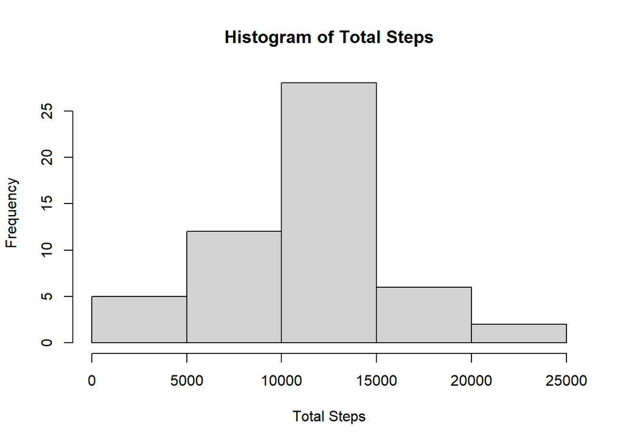

```r
aggregate_step_by_day <- aggregate(steps ~ date, data, sum, na.rm = T)
hist(aggregate_step_by_day$steps, xlab = "Total Steps", main = "Histogram of Total Steps")
```

```r
mean(aggregate_step_by_day$steps)
```

```
## [1] 10766.19
```

```r
median(aggregate_step_by_day$steps)
```

```
## [1] 10765
```

## What is the average daily activity pattern?

Time series of the 5-minute intervals and the average number of steps taken averaged across all days is plotted. 5-minute interval that contains the maximum number of steps is found.

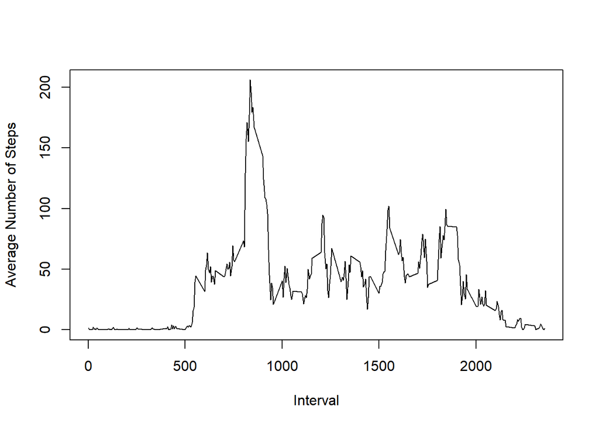

```r
aggregate_maxstep_by_interval <- aggregate(steps ~ interval, data, mean, na.rm = T)
plot(aggregate_maxstep_by_interval$interval, aggregate_maxstep_by_interval$steps,
     type = "l", ylab = "Average Number of Steps", xlab = "Interval")
```

```r
maxstep_by_interval <- aggregate_maxstep_by_interval[which.max(aggregate_maxstep_by_interval$steps), 1]
maxstep_by_interval
```

```
## [1] 835
```

## Imputing missing values

Total number of NA values in steps column is found. Missing values are imputed using the 5-minute interval averages. New data set called "data_filled" is created with imputed NA values. Histogram of the total number of steps taken each day, mean, and median are found. The mean stays approximately the same because we are imputed the missing values with the 5-minute interval means. Median value is shifted a little bit, but it is mainly caused by the positions of missing values.

```r
sum(is.na(data$steps))
```

```
## [1] 2304
```

```r
meanInterval <- function(x){
  aggregate_maxstep_by_interval[aggregate_maxstep_by_interval$interval == x,]$steps
}
data_filled <- data
for(i in 1:nrow(data_filled)){
  if(is.na(data_filled[i, ]$steps)){
    data_filled[i, ]$steps <- meanInterval(data_filled[i, ]$interval)
  }
}
sum(is.na(data_filled$steps))
```

```
## [1] 0
```

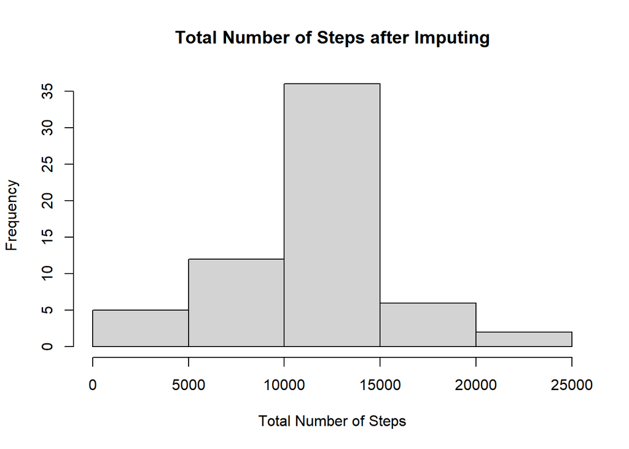

```r
aggregate_step_by_day_filled <- aggregate(steps ~ date, data_filled, sum)
hist(aggregate_step_by_day_filled$steps, main = "Total Number of Steps after Imputing",
     xlab = "Total Number of Steps")
```

```r
mean(aggregate_step_by_day_filled$steps)
```

```
## [1] 10766.19
```

```r
median(aggregate_step_by_day_filled$steps)
```

```
## [1] 10766.19
```

## Are there differences in activity patterns between weekdays and weekends?

For this part of the project, "lubridate" package is used for identifying the weekends and weekdays. "day" column is consisted of 2 level factor with levels "weekday" and "weekend". "lattice" package is used for plotting the time series plot of 5-minute interval and the average number of steps taken, averaged across all weekdays or weekend days.

```r
library(lubridate)
data_filled$date <- ymd(data_filled$date)
for(i in 1:nrow(data_filled)){
  if(wday(data_filled$date[i]) == 1 | wday(data_filled$date[i]) == 7){
    data_filled$day[i] <- "weekend"
  }
  else{
    data_filled$day[i] <- "weekday"
  }
}
data_filled$day <- factor(data_filled$day, levels = c("weekday", "weekend"))
unique(data_filled[data_filled$day == "weekend", ]$date)
```

```
##  [1] "2012-10-06" "2012-10-07" "2012-10-13" "2012-10-14" "2012-10-20"
##  [6] "2012-10-21" "2012-10-27" "2012-10-28" "2012-11-03" "2012-11-04"
## [11] "2012-11-10" "2012-11-11" "2012-11-17" "2012-11-18" "2012-11-24"
## [16] "2012-11-25"
```

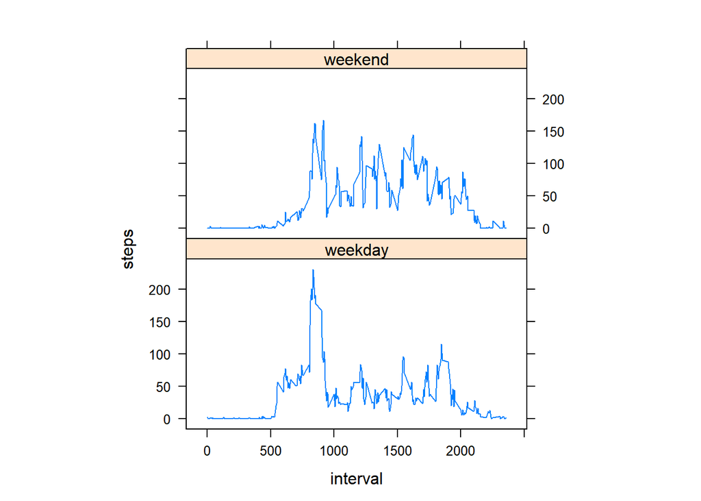

```r
library(lattice)
aggregated <- aggregate(steps ~ interval + day, data_filled, mean)
xyplot(steps ~ interval | factor(day), data = aggregated, aspect = 1/2, type = "l")
```